# Monte Carlo and Markov Chain Monte Carlo

Jeff

2026-04-10

# Monte Carlo Approximation

We discussed in lecture that difficult integration problems become easy summation problems if we can sample observations from the probability density function in question.

Our main example of this was pretending that a Gaussian mixture model could be considered `tricky’ to find an expected value for. We assume the pdf is
$$f(x) = 0.4 \phi(x \mid \mu_1=0,
\sigma_1^2=1) + 0.6 \phi(x \mid \mu_2=5, \sigma^2_2=1)$$
and then set up a sampling framework to show that we can estimate $E[X]$ via the observed samples.

The following code sets up an observed sample from the mixture of size $n=100,000$. It’s a somewhat lazy, though efficient in terms of R code, way of getting this done. Admittedly, it will cause some warnings…

```r
set.seed(5211343)
all1 <- rnorm(100000)
all2 <- rnorm(100000, 5)
indsamp <- sample(c(1,2), 100000, replace=TRUE, prob=c(0.4, 0.6) )
obsamp <- indsamp
obsamp[indsamp==1] <- all1
```

```
## Warning in obsamp[indsamp == 1] <- all1: number of items to replace is not a
## multiple of replacement length
```

```r
obsamp[indsamp==2] <- all2
```

```
## Warning in obsamp[indsamp == 2] <- all2: number of items to replace is not a
## multiple of replacement length
```

Then, we can view how our estimate improves towards the true $E[X]$ as the sample size grows.

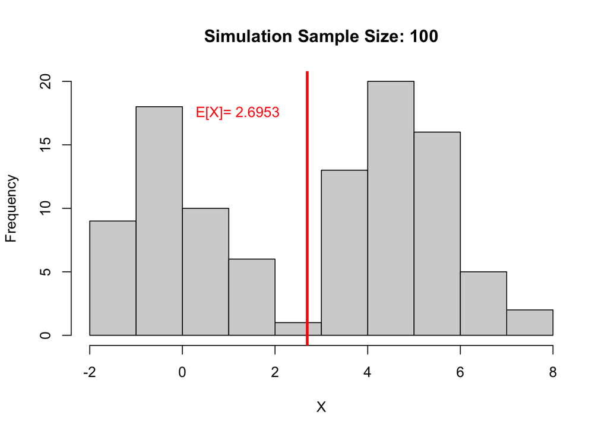

```r
hist(obsamp[1:100], main="Simulation Sample Size: 100", xlab="X")
abline(v=mean(obsamp[1:100]), col="red", lwd=3)
text(mean(obsamp[1:100])-1.5, 17.5, labels=paste("E[X]=",round(mean(obsamp[1:100]), 4)), col="red")
```

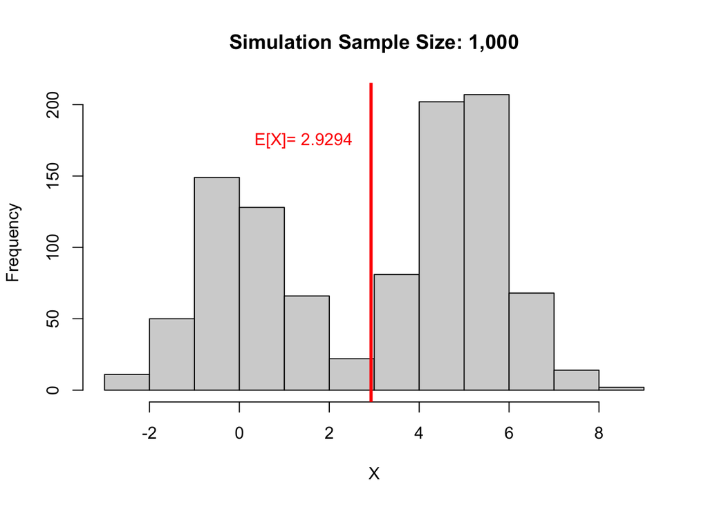

```r
hist(obsamp[1:1000], main="Simulation Sample Size: 1,000", xlab="X")
abline(v=mean(obsamp[1:1000]), col="red", lwd=3)
text(mean(obsamp[1:1000])-1.5, 175, labels=paste("E[X]=",round(mean(obsamp[1:1000]), 4)), col="red")
```

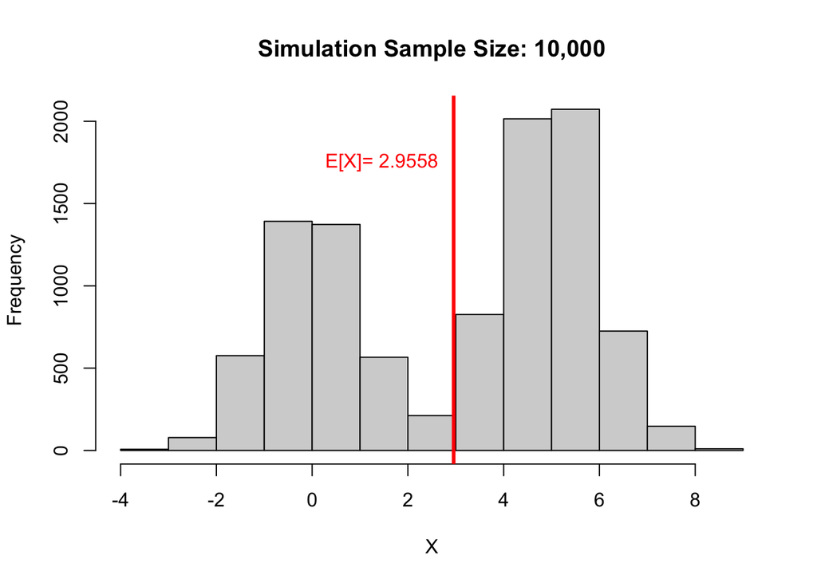

```r
hist(obsamp[1:10000], main="Simulation Sample Size: 10,000", xlab="X")
abline(v=mean(obsamp[1:10000]), col="red", lwd=3)
text(mean(obsamp[1:10000])-1.5, 1750, labels=paste("E[X]=",round(mean(obsamp[1:10000]), 4)), col="red")
```

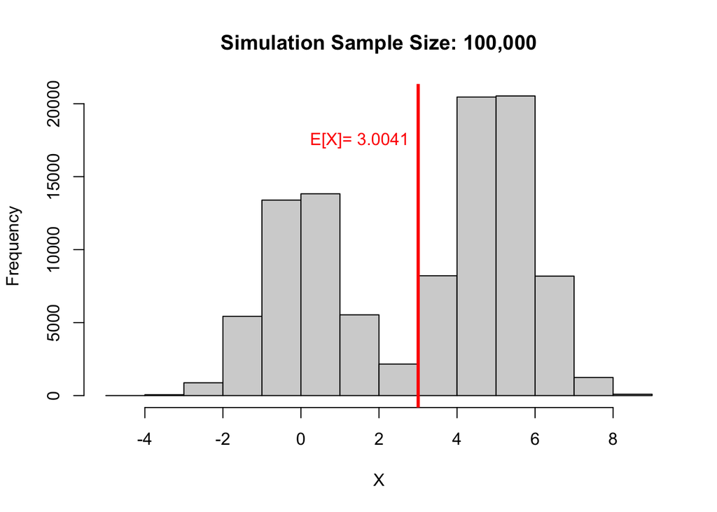

```r
hist(obsamp[1:100000], main="Simulation Sample Size: 100,000", xlab="X")
abline(v=mean(obsamp[1:100000]), col="red", lwd=3)
text(mean(obsamp[1:100000])-1.5, 17500, labels=paste("E[X]=",round(mean(obsamp[1:100000]), 4)), col="red")
```

# Rejection Sampling

Sampling from a well known distribution is pretty straightforward, but our primary problem in the Bayesian framework is that we may not know the probability distribution beyond some proportional representation of it. It turns out this isn’t a problem for a good number of our standard sampling approaches.

We put forward an example of using a Beta prior for $\mu$ from a normal distribution (with known $\sigma^2$). In our example, we end up with the following unnormalized posterior distribution.

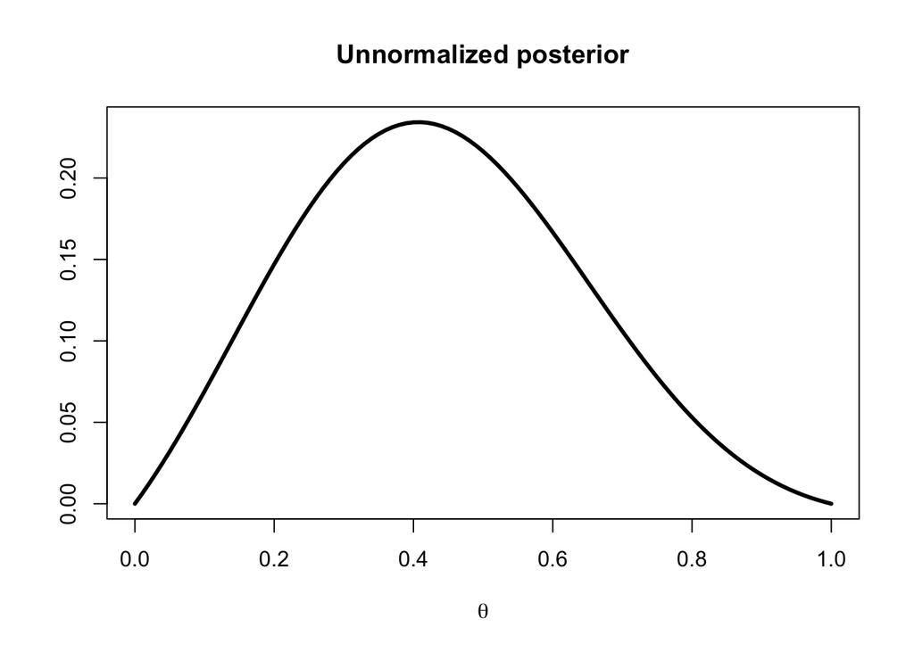

```r
curve(exp((-0.5*(x-.33)^2)/(1/10))*x*(1-x), from=0, to=1, ylab="", xlab=expression(theta), main="Unnormalized posterior", lwd=3)
```

Given our prior, our $\mu$ is only defined on the domain [0,1], so we setup this unnormalized posterior distribution function as

```r
betanorm <- Vectorize(function(x){
  if((x<0)|(x>1)){store <- 0}
  else{
    store <- exp((-0.5*(x-.33)^2)/(1/10))*x*(1-x)
  }
  store
}, vectorize.args = "x")
```

As discussed in lecture, rejection sampling is an extremely simple framework to generate samples under any distribution, and can easily deal with unnormalized distributions through a scaling parameter $M$.

Given the plot shown earlier, I suggested we could use $M=0.3$ and a standard uniform distribution as the proposal distribution. Here’s the code to set up the rejection sampling algorithm under those settings:

```r
rejsamp_unif <- function(n, M=.3){
  un1 <- runif(n)
  un2 <- runif(n)
  R <- betanorm(un1)/dunif(un1)
  un1[R>M*un2]
}
```

Then we just generate our sample of whatever size we want. Note that in this case, size is referring to how many proposal samples we try. Of course, if we needed a particular sample size from the target distribution, we would have to keep increasing the proposal sample size until we hit that target. For my example, I simply took 100,000 as the proposal sample size.

```r
set.seed(122351)
rejexam <- rejsamp_unif(100000)
length(rejexam) #target distribution sample size
```

```
## [1] 40696
```

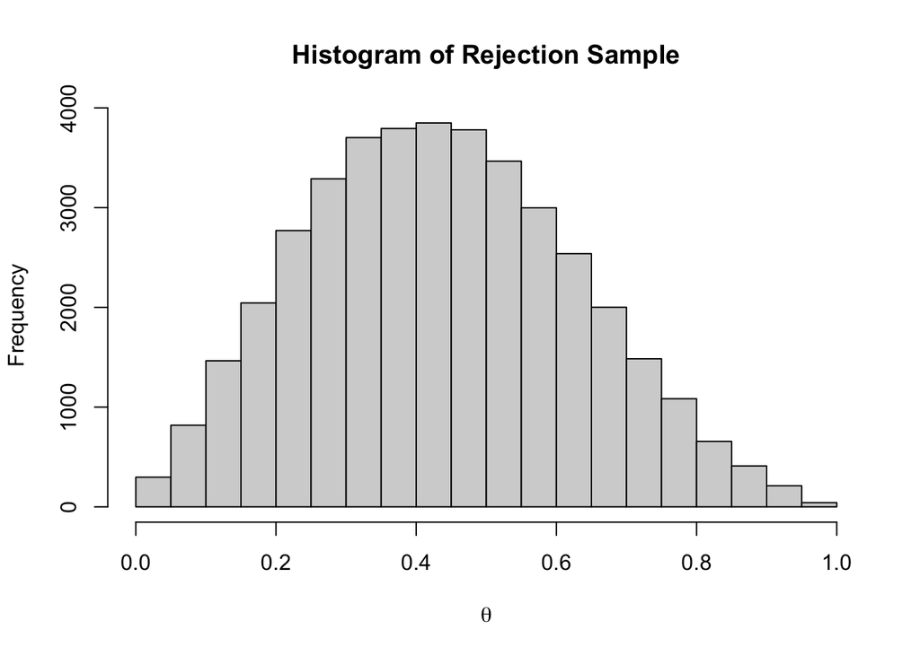

```r
hist(rejexam, main="Histogram of Rejection Sample", xlab=expression(theta))
```

For certain types of distributions, and especially multivariate ones, these types of independent sampling techniques become extremely inefficient where the chance of `acceptances’ during the algorithm can become very, very low.

# Metropolis-Hasting MCMC

Markov Chain Monte Carlo techniques instead take advantage of dependent sampling (where the next sample is explicitly dependent on the location of the previous sample). When constructed carefully, the resulting sample can be used in the same way as an independent sample would be.

Here we construct the Metropolis-Hasting MCMC sample for the same problem, following the assumptions stated in the lecture.

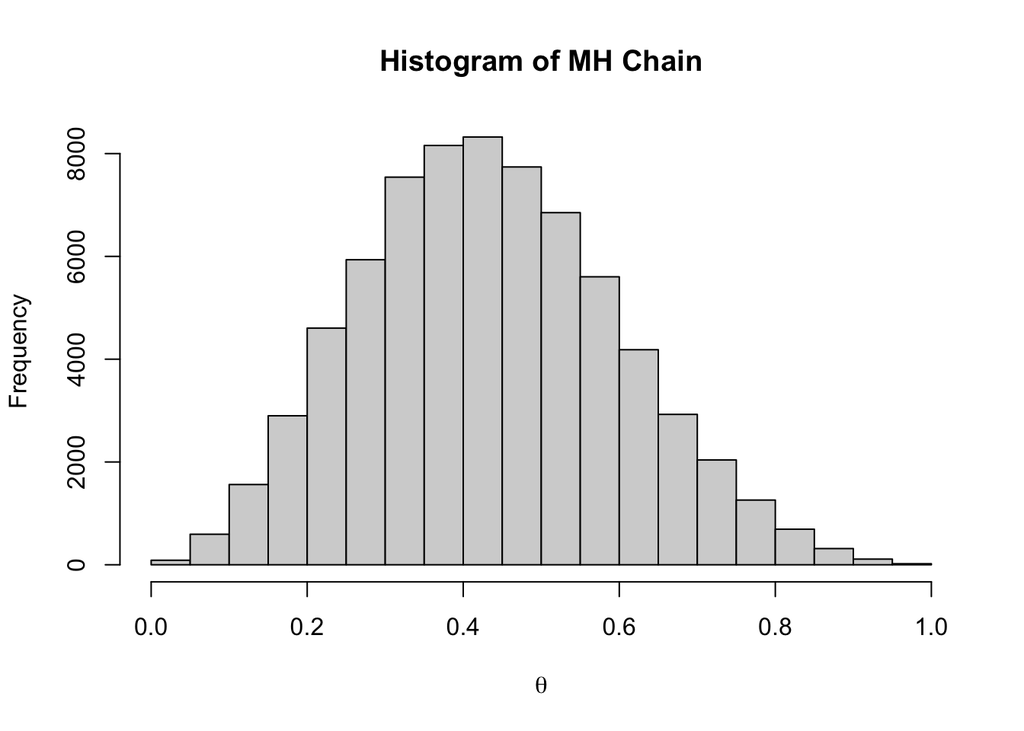

```r
mh_mcmc <- function(n, theta=0.2){
  rns <- rnorm(n, sd=0.2)
  retained <- TRUE
  for(i in 1:n){
    y <- theta[i] + rns[i]
    a <- min(c(1,betanorm(y)/betanorm(theta[i])))
    retained[i+1] <- sample(c(TRUE,FALSE),1, prob=c(a, 1-a))
    theta[i+1] <- sample(c(y,theta[i]),1, prob=c(a, 1-a))
  }
  list(fullchain=theta, sample=theta[retained])
}

test <- mh_mcmc(100000)
hist(test$sample, main="Histogram of MH Chain", xlab=expression(theta))
```